# Machine Learning Writeup

DanLau

Saturday, April 25, 2015

Background

Using devices such as Jawbone Up, Nike FuelBand, and Fitbit it is now possible to collect a large amount of data about personal activity relatively inexpensively. These type of devices are part of the quantified self movement - a group of enthusiasts who take measurements about themselves regularly to improve their health, to find patterns in their behavior, or because they are tech geeks. One thing that people regularly do is quantify how much of a particular activity they do, but they rarely quantify how well they do it. In this project, your goal will be to use data from accelerometers on the belt, forearm, arm, and dumbell of 6 participants. They were asked to perform barbell lifts correctly and incorrectly in 5 different ways. More information is available from the website here: http://groupware.les.inf.puc-rio.br/har (see the section on the Weight Lifting Exercise Dataset). The goal is to build a machine learning algorithm to predict activity quality from activity monitors

We first load the library we will need and the dataset.

## Loading the library and the dataset

```r
library(caret); library(randomForest);library(e1071)
```

```r
training_url<-"http://d396qusza40orc.cloudfront.net/predmachlearn/pml-training.csv"
test_url<-"http://d396qusza40orc.cloudfront.net/predmachlearn/pml-testing.csv"
```

To begin, we read and cleanup the training and testing dataset in order to remove variables that are not useful.

## Read and cleanup the data

```r
test<-read.csv(test_url,header = TRUE, as.is = TRUE, na.strings=c("NA",""))
train <- read.csv(training_url, header = TRUE, as.is = TRUE, na.strings=c("", "NA"))
names(train); dim(train)
```

```
##   [1] "X"                        "user_name"
##   [3] "raw_timestamp_part_1"     "raw_timestamp_part_2"
##   [5] "cvtd_timestamp"           "new_window"
##   [7] "num_window"               "roll_belt"
##   [9] "pitch_belt"               "yaw_belt"
##  [11] "total_accel_belt"         "kurtosis_roll_belt"
##  [13] "kurtosis_picth_belt"      "kurtosis_yaw_belt"
##  [15] "skewness_roll_belt"       "skewness_roll_belt.1"
##  [17] "skewness_yaw_belt"        "max_roll_belt"
##  [19] "max_picth_belt"           "max_yaw_belt"
##  [21] "min_roll_belt"            "min_pitch_belt"
##  [23] "min_yaw_belt"             "amplitude_roll_belt"
##  [25] "amplitude_pitch_belt"     "amplitude_yaw_belt"
##  [27] "var_total_accel_belt"     "avg_roll_belt"
##  [29] "stddev_roll_belt"         "var_roll_belt"
```

[output cut: 65 more lines]

```
## [1] 19622   160
```

```r
## remove columns is simply an index, timestamp or username and also with blank and NAs
train <- train[,-c(1:7)]
test <- test[,-c(1:7)]
test <- test[,colSums(is.na(test)) == 0]; dim(test); head(test)
```

```
## [1] 20 53
```

```
##   roll_belt pitch_belt yaw_belt total_accel_belt gyros_belt_x gyros_belt_y
## 1    123.00      27.00    -4.75               20        -0.50        -0.02
## 2      1.02       4.87   -88.90                4        -0.06        -0.02
## 3      0.87       1.82   -88.50                5         0.05         0.02
## 4    125.00     -41.60   162.00               17         0.11         0.11
## 5      1.35       3.33   -88.60                3         0.03         0.02
## 6     -5.92       1.59   -87.70                4         0.10         0.05
##   gyros_belt_z accel_belt_x accel_belt_y accel_belt_z magnet_belt_x
## 1        -0.46          -38           69         -179           -13
## 2        -0.07          -13           11           39            43
## 3         0.03            1           -1           49            29
## 4        -0.16           46           45         -156           169
## 5         0.00           -8            4           27            33
## 6        -0.13          -11          -16           38            31
##   magnet_belt_y magnet_belt_z roll_arm pitch_arm yaw_arm total_accel_arm
```

[output cut: 69 more lines]

```r
train <- train[,colSums(is.na(train)) == 0]; dim(train)
```

```
## [1] 19622    53
```

```r
head(train)
```

```
##   roll_belt pitch_belt yaw_belt total_accel_belt gyros_belt_x gyros_belt_y
## 1      1.41       8.07    -94.4                3         0.00         0.00
## 2      1.41       8.07    -94.4                3         0.02         0.00
## 3      1.42       8.07    -94.4                3         0.00         0.00
## 4      1.48       8.05    -94.4                3         0.02         0.00
## 5      1.48       8.07    -94.4                3         0.02         0.02
## 6      1.45       8.06    -94.4                3         0.02         0.00
##   gyros_belt_z accel_belt_x accel_belt_y accel_belt_z magnet_belt_x
## 1        -0.02          -21            4           22            -3
## 2        -0.02          -22            4           22            -7
## 3        -0.02          -20            5           23            -2
## 4        -0.03          -22            3           21            -6
## 5        -0.02          -21            2           24            -6
## 6        -0.02          -21            4           21             0
##   magnet_belt_y magnet_belt_z roll_arm pitch_arm yaw_arm total_accel_arm
```

[output cut: 69 more lines]

```r
## the variable "classe is our outcome so we convert it into factor
class(train$classe)
```

```
## [1] "character"
```

```r
train$classe <- as.factor(train$classe)
```

## Cross validation and splitting tha data into 65% training and 35% testing set

```r
set.seed(22344)
setTrain <- createDataPartition(y = train$classe, p = 0.65, list = FALSE)
trainPml <- train[setTrain,]
testPml <- train[-setTrain,]
dim(trainPml); dim(testPml)
```

```
## [1] 12757    53
```

```
## [1] 6865   53
```

For the prediction models I will use the random forest and naive bayes model.

## Random Forest model

```r
modPmlRf<- randomForest(classe ~. , data = trainPml)
print(modPmlRf)
```

```
##
## Call:
##  randomForest(formula = classe ~ ., data = trainPml)
##                Type of random forest: classification
##                      Number of trees: 500
## No. of variables tried at each split: 7
##
##         OOB estimate of  error rate: 0.63%
## Confusion matrix:
##      A    B    C    D    E class.error
## A 3621    5    0    0    1 0.001654260
## B    9 2453    7    0    0 0.006480356
## C    0   15 2204    6    0 0.009438202
## D    0    0   26 2064    1 0.012912482
## E    0    0    2    8 2335 0.004264392
```

```r
## To summarize the model we use the confusion matrix on the training and testing set
## In-sample accuracy
confusionMatrix(predict(modPmlRf, trainPml), trainPml$classe)
```

```
## Confusion Matrix and Statistics
##
##           Reference
## Prediction    A    B    C    D    E
##          A 3627    0    0    0    0
##          B    0 2469    0    0    0
##          C    0    0 2225    0    0
##          D    0    0    0 2091    0
##          E    0    0    0    0 2345
##
## Overall Statistics
##
##                Accuracy : 1
##                  95% CI : (0.9997, 1)
##     No Information Rate : 0.2843
##     P-Value [Acc > NIR] : < 2.2e-16
##
##                   Kappa : 1
##  Mcnemar's Test P-Value : NA
##
## Statistics by Class:
##
##                      Class: A Class: B Class: C Class: D Class: E
## Sensitivity            1.0000   1.0000   1.0000   1.0000   1.0000
## Specificity            1.0000   1.0000   1.0000   1.0000   1.0000
## Pos Pred Value         1.0000   1.0000   1.0000   1.0000   1.0000
## Neg Pred Value         1.0000   1.0000   1.0000   1.0000   1.0000
## Prevalence             0.2843   0.1935   0.1744   0.1639   0.1838
## Detection Rate         0.2843   0.1935   0.1744   0.1639   0.1838
## Detection Prevalence   0.2843   0.1935   0.1744   0.1639   0.1838
## Balanced Accuracy      1.0000   1.0000   1.0000   1.0000   1.0000
```

```r
## Out-sample accuracy
confusionMatrix(predict(modPmlRf, testPml), testPml$classe)
```

```
## Confusion Matrix and Statistics
##
##           Reference
## Prediction    A    B    C    D    E
##          A 1952    4    0    4    0
##          B    0 1324   11    0    0
##          C    0    0 1184   10    3
##          D    0    0    2 1111    4
##          E    1    0    0    0 1255
##
## Overall Statistics
##
##                Accuracy : 0.9943
##                  95% CI : (0.9922, 0.996)
##     No Information Rate : 0.2845
##     P-Value [Acc > NIR] : < 2.2e-16
##
##                   Kappa : 0.9928
##  Mcnemar's Test P-Value : NA
##
## Statistics by Class:
##
##                      Class: A Class: B Class: C Class: D Class: E
## Sensitivity            0.9995   0.9970   0.9891   0.9876   0.9945
## Specificity            0.9984   0.9980   0.9977   0.9990   0.9998
## Pos Pred Value         0.9959   0.9918   0.9891   0.9946   0.9992
## Neg Pred Value         0.9998   0.9993   0.9977   0.9976   0.9988
## Prevalence             0.2845   0.1934   0.1744   0.1639   0.1838
## Detection Rate         0.2843   0.1929   0.1725   0.1618   0.1828
## Detection Prevalence   0.2855   0.1945   0.1744   0.1627   0.1830
## Balanced Accuracy      0.9989   0.9975   0.9934   0.9933   0.9971
```

The in sample accuracy is 100 % which indicates, the model is quite good. The cross validation accuracy is 99%, meaning that our model is constant and can be sufficient for predicting the twenty test observations. Based on the lower bound of the confidence interval we would expect to achieve a 99.22% of accuracy for the classification of the data provided.

## Naive bayes model

```r
modPmlNb <- naiveBayes(classe ~. , data = trainPml)
print(modPmlNb)
```

```
##
## Naive Bayes Classifier for Discrete Predictors
##
## Call:
## naiveBayes.default(x = X, y = Y, laplace = laplace)
##
## A-priori probabilities:
## Y
##         A         B         C         D         E
## 0.2843145 0.1935408 0.1744140 0.1639100 0.1838206
##
## Conditional probabilities:
##    roll_belt
## Y       [,1]     [,2]
##   A 58.92964 60.21263
##   B 66.39872 59.88443
##   C 64.26900 61.06453
##   D 59.67918 61.34105
##   E 75.68720 70.44982
##
##    pitch_belt
## Y         [,1]     [,2]
##   A  0.4356603 23.50674
##   B  0.1618145 23.73463
##   C -1.0927820 22.68874
##   D  1.8686083 20.80288
##   E  0.5668145 19.20737
##
##    yaw_belt
## Y         [,1]     [,2]
##   A -12.698839 99.79065
##   B -12.332949 95.91127
##   C  -7.823326 98.17430
##   D -19.401765 88.56481
##   E  -4.171633 87.69810
##
##    total_accel_belt
## Y       [,1]     [,2]
##   A 10.62421 7.304480
##   B 11.31187 7.469111
```

[output cut: 372 more lines]

```
##    magnet_forearm_y
## Y       [,1]     [,2]
##   A 471.1952 430.4628
##   B 284.6104 579.6654
##   C 511.9739 414.8827
##   D 322.2898 494.0029
##   E 274.8166 575.1716
##
##    magnet_forearm_z
## Y       [,1]     [,2]
##   A 406.1318 355.3714
##   B 384.7906 395.0569
##   C 461.1955 350.4393
##   D 359.6380 356.5265
##   E 354.5522 384.4183
```

```r
## Summarize the results
## In-sample accuracy
confusionMatrix(predict(modPmlNb, newdata = trainPml), trainPml$classe)
```

```
## Confusion Matrix and Statistics
##
##           Reference
## Prediction    A    B    C    D    E
##          A 2309  302  495  211  124
##          B  196 1526  266   63  431
##          C  593  310 1118  598  232
##          D  427  156  241  982  312
##          E  102  175  105  237 1246
##
## Overall Statistics
##
##                Accuracy : 0.5629
##                  95% CI : (0.5542, 0.5715)
##     No Information Rate : 0.2843
##     P-Value [Acc > NIR] : < 2.2e-16
##
##                   Kappa : 0.4485
##  Mcnemar's Test P-Value : < 2.2e-16
##
## Statistics by Class:
##
##                      Class: A Class: B Class: C Class: D Class: E
## Sensitivity            0.6366   0.6181  0.50247  0.46963  0.53134
## Specificity            0.8760   0.9071  0.83545  0.89349  0.94055
## Pos Pred Value         0.6710   0.6148  0.39214  0.46364  0.66810
## Neg Pred Value         0.8585   0.9082  0.88825  0.89576  0.89910
## Prevalence             0.2843   0.1935  0.17441  0.16391  0.18382
## Detection Rate         0.1810   0.1196  0.08764  0.07698  0.09767
## Detection Prevalence   0.2697   0.1946  0.22349  0.16603  0.14619
## Balanced Accuracy      0.7563   0.7626  0.66896  0.68156  0.73595
```

```r
## Out-sample accuracy
confusionMatrix(predict(modPmlNb, newdata = testPml), testPml$classe)
```

```
## Confusion Matrix and Statistics
##
##           Reference
## Prediction    A    B    C    D    E
##          A 1251  146  248  113   66
##          B  100  843  159   39  244
##          C  344  160  620  309  133
##          D  203   81  123  545  167
##          E   55   98   47  119  652
##
## Overall Statistics
##
##                Accuracy : 0.5697
##                  95% CI : (0.5579, 0.5815)
##     No Information Rate : 0.2845
##     P-Value [Acc > NIR] : < 2.2e-16
##
##                   Kappa : 0.4573
##  Mcnemar's Test P-Value : < 2.2e-16
##
## Statistics by Class:
##
##                      Class: A Class: B Class: C Class: D Class: E
## Sensitivity            0.6406   0.6348  0.51796  0.48444  0.51664
## Specificity            0.8833   0.9021  0.83310  0.90000  0.94307
## Pos Pred Value         0.6859   0.6087  0.39591  0.48704  0.67147
## Neg Pred Value         0.8607   0.9115  0.89111  0.89906  0.89650
## Prevalence             0.2845   0.1934  0.17436  0.16387  0.18383
## Detection Rate         0.1822   0.1228  0.09031  0.07939  0.09497
## Detection Prevalence   0.2657   0.2017  0.22811  0.16300  0.14144
## Balanced Accuracy      0.7619   0.7685  0.67553  0.69222  0.72985
```

The in sample accuracy is 56 % which indicates that random forest is the best the model for these data.

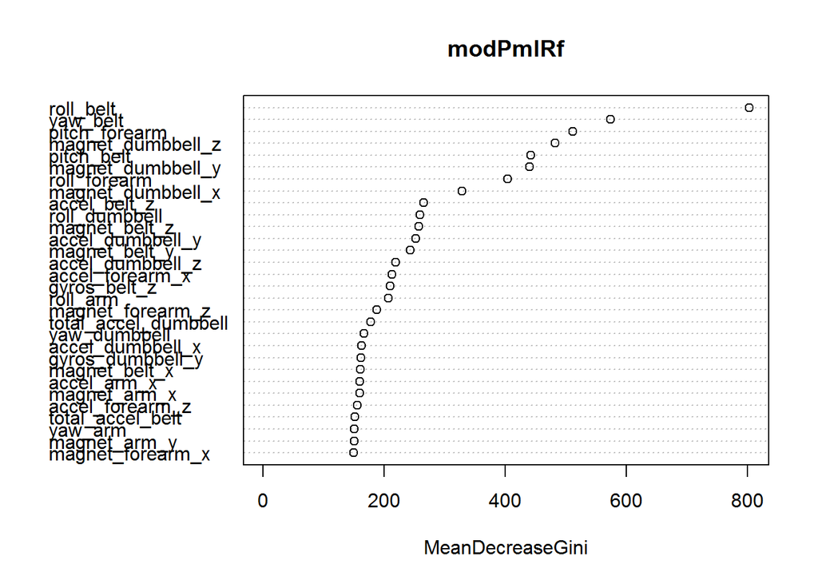

```r
## We can plot the variable importance from the random forest
varImpPlot(modPmlRf)
```

## Prediction of Test set provided

```r
answers = predict(modPmlRf, test)
pml_write_files = function(x){
  n = length(x)
  for(i in 1:n){
    filename = paste0("problem_id_",i,".txt")
    write.table(x[i],file=filename,quote=FALSE,row.names=FALSE,col.names=FALSE)
  }
}
pml_write_files(answers)
```

## Conclusion

To conclude we can say that weight lifting style can be well predicted as measured with accelerometers and the roll belt are the is the most important to quantify the impact of the classe variable.